# PEEP II Ratings & Acoustics

Rick O. Gilmore

2019-06-14 18:56:15

# 1 Setup

# 2 Purpose

1. To create a reproducible data cleaning and visualization pipeline.
2. To visualize the PEEP-II ratings and acoustic data.
3. To conduct confirmatory and exploratory analyses on these data.

# 3 Data acquisition

## 3.1 Import locally

The data are in `data/csv/long_speaker_acous_ratings_6.14.19.csv“.

```r
ratings_acoustics <- readr::read_csv("data/csv/long_speaker_acous_ratings_6.14.19.csv")
```

## 3.2 Import from Databrary

This is not working yet.

```r
peep_II_vol <- 339
```

# 4 Clean

## 4.1 Inspect

```r
str(ratings_acoustics)
```

```
## Classes 'spec_tbl_df', 'tbl_df', 'tbl' and 'data.frame': 2400 obs. of  9 variables:
##  $ Subject     : num  1 1 1 1 1 1 1 1 1 1 ...
##  $ Speaker     : num  0 0 1 1 0 0 1 1 0 0 ...
##  $ Prosody     : num  1 1 1 1 1 1 1 1 1 1 ...
##  $ Happy_rating: num  1 1 1 1 2 1 1 1 1 1 ...
##  $ Angry_rating: num  2 4 4 2 3 4 4 3 4 4 ...
##  $ Sad_Rating  : num  2 2 1 2 2 2 2 2 2 2 ...
##  $ F0_Mean     : num  219 187 355 224 189 ...
##  $ F0_SD       : num  69.9 38.2 92.2 53.2 44.5 ...
##  $ Speech_Rate : num  3.34 3.4 4.3 3.66 3.54 ...
##  - attr(*, "spec")=
##   .. cols(
##   ..   Subject = col_double(),
##   ..   Speaker = col_double(),
##   ..   Prosody = col_double(),
##   ..   Happy_rating = col_double(),
##   ..   Angry_rating = col_double(),
##   ..   Sad_Rating = col_double(),
##   ..   F0_Mean = col_double(),
##   ..   F0_SD = col_double(),
##   ..   Speech_Rate = col_double()
##   .. )
```

`Subject` is an integer. Does it correspond to the `Participant ID`?

```r
unique(ratings_acoustics$Subject)
```

```
##  [1]  1  2  3  5  6  8  9 11 12 13 14 15 18 19 21 22 23 24 26 28 30 31 32
## [24] 33 35 36 37 38 39 41 42 47 49 50 51 52 53 54 56 57 58 59 60 61 62 63
## [47] 66 68 69 70 72
```

```r
length(unique(ratings_acoustics$Subject))
```

```
## [1] 51
```

Yes, it appears to be the case that `Subject` == `Participant ID`. This corresponds to the `session_name` variable in the Databrary volume. The Databrary volume (https://nyu.databrary.org/volume/339) only has recordings up through participant 53, however.

## 4.2 Add demographic data

We can add demographic data by merging the `ratings_acoustics` file with the Databrary spreadsheet.

```r
# Login required
databraryapi::login_db(email = params$db_account)
```

```
## Login successful.
```

```
## [1] TRUE
```

```r
# Download session CSV
vol_39_demo <- databraryapi::download_session_csv(vol_id = peep_II_vol)
str(vol_39_demo)
```

```
## 'data.frame':    32 obs. of  24 variables:
##  $ session_id             : int  16956 16957 16958 16959 16960 16961 16962 17032 17033 17034 ...
##  $ session_name           : int  1 3 5 6 7 8 9 11 13 14 ...
##  $ session_date           : Factor w/ 2 levels "","materials": 1 1 1 1 1 1 1 1 1 1 ...
##  $ session_release        : Factor w/ 2 levels "","EXCERPTS": 2 2 2 2 2 2 2 2 2 2 ...
##  $ participant1.ID        : Factor w/ 32 levels "","001c","003c",..: 2 3 4 5 6 7 8 9 11 12 ...
##  $ participant1.birthdate : Factor w/ 30 levels "","2007-07-11",..: 2 6 8 7 24 3 11 13 10 15 ...
##  $ participant1.gender    : Factor w/ 3 levels "","Female","Male": 2 2 3 2 2 2 3 2 2 3 ...
##  $ participant1.race      : Factor w/ 3 levels "","More than one",..: 3 3 3 3 3 3 3 3 3 3 ...
##  $ participant1.ethnicity : Factor w/ 3 levels "","Hispanic or Latino",..: 3 3 3 3 3 3 3 3 2 3 ...
##  $ participant1.disability: Factor w/ 2 levels "","typical": 2 2 2 2 2 2 2 2 2 2 ...
##  $ participant1.language  : Factor w/ 2 levels "","English": 2 2 2 2 2 2 2 2 2 2 ...
##  $ participant1.country   : Factor w/ 2 levels "","US": 2 2 2 2 2 2 2 2 2 2 ...
##  $ participant1.state     : Factor w/ 2 levels "","PA": 2 2 2 2 2 2 2 2 2 2 ...
##  $ participant1.setting   : logi  NA NA NA NA NA NA ...
##  $ participant2.ID        : Factor w/ 32 levels "","001m","003m",..: 2 3 4 5 6 7 8 9 11 12 ...
##  $ participant2.birthdate : Factor w/ 32 levels "","1967-12-05",..: 5 4 6 12 29 7 28 8 30 31 ...
##  $ participant2.gender    : Factor w/ 2 levels "","Female": 2 2 2 2 2 2 2 2 2 2 ...
##  $ participant2.race      : Factor w/ 3 levels "","More than one",..: 3 3 3 3 3 3 3 3 3 3 ...
##  $ participant2.ethnicity : Factor w/ 3 levels "","Hispanic or Latino",..: 3 3 3 3 3 3 3 3 2 3 ...
##  $ participant2.disability: Factor w/ 2 levels "","typical": 2 2 2 2 2 2 2 2 2 2 ...
##  $ participant2.language  : Factor w/ 3 levels "","English","Slovenian": 2 2 2 2 2 2 2 2 2 2 ...
##  $ participant2.country   : Factor w/ 2 levels "","US": 2 2 2 2 2 2 2 2 2 2 ...
##  $ participant2.state     : Factor w/ 2 levels "","PA": 1 2 2 2 2 2 2 2 2 2 ...
##  $ participant2.setting   : logi  NA NA NA NA NA NA ...
```

The `session_name` variable seems to correspond with the dyad’s participant number, as deduced previously.

```r
vol_39_clean <- vol_39_demo %>%
  dplyr::filter(!is.na(session_name)) %>% # drop materials
  dplyr::select(-participant1.birthdate, -participant2.birthdate) %>% # Birthdates
  dplyr::select(session_name,
                participant1.gender, participant1.race, participant1.ethnicity,
                participant2.race, participant2.ethnicity) %>%
  dplyr::rename(child_gender = participant1.gender,
                child_race = participant1.race,
                child_ethnicity = participant1.ethnicity,
                mother_race = participant2.race,
                mother_ethnicity = participant2.ethnicity)
```

Now, we merge the ratings data with the demographic data.

```r
ratings_acoustics_all <- dplyr::left_join(ratings_acoustics, vol_39_clean, by = c("Subject" = "session_name"))
```

## 4.3 Refactor to make names explicit

1. Speaker is in {0,1}. Which is familiar and which novel?
2. Prosody is in {1,2,3}. How do these map to angry, happy, sad?
3. Units of F0_mean must be Hz. So must F0_SD. What about speech rate?

## 4.4 Add back or acquire script and order variables

# 5 Visualizations

## 5.1 Intensity ratings by target prosody

Create a single variable from the {Happy, Angry, Sad}_Rating variables.

```r
ratings_acoustics_gathered <- ratings_acoustics_all %>%
  tidyr::gather(., key = "Prosody", value = "Intensity_Rating", 4:6) %>%
  dplyr::select_all() %>%
  dplyr::mutate(., Target_Prosody = stringr::str_extract(Prosody, 'Happy|Angry|Sad'))

str(ratings_acoustics_gathered)
```

```
## Classes 'tbl_df', 'tbl' and 'data.frame':    7200 obs. of  13 variables:
##  $ Subject         : num  1 1 1 1 1 1 1 1 1 1 ...
##  $ Speaker         : num  0 0 1 1 0 0 1 1 0 0 ...
##  $ F0_Mean         : num  219 187 355 224 189 ...
##  $ F0_SD           : num  69.9 38.2 92.2 53.2 44.5 ...
##  $ Speech_Rate     : num  3.34 3.4 4.3 3.66 3.54 ...
##  $ child_gender    : Factor w/ 3 levels "","Female","Male": 2 2 2 2 2 2 2 2 2 2 ...
##  $ child_race      : Factor w/ 3 levels "","More than one",..: 3 3 3 3 3 3 3 3 3 3 ...
##  $ child_ethnicity : Factor w/ 3 levels "","Hispanic or Latino",..: 3 3 3 3 3 3 3 3 3 3 ...
##  $ mother_race     : Factor w/ 3 levels "","More than one",..: 3 3 3 3 3 3 3 3 3 3 ...
##  $ mother_ethnicity: Factor w/ 3 levels "","Hispanic or Latino",..: 3 3 3 3 3 3 3 3 3 3 ...
##  $ Prosody         : chr  "Happy_rating" "Happy_rating" "Happy_rating" "Happy_rating" ...
##  $ Intensity_Rating: num  1 1 1 1 2 1 1 1 1 1 ...
##  $ Target_Prosody  : chr  "Happy" "Happy" "Happy" "Happy" ...
```

### 5.1.1 Intensity_Rating by Target_Prosody by Speaker

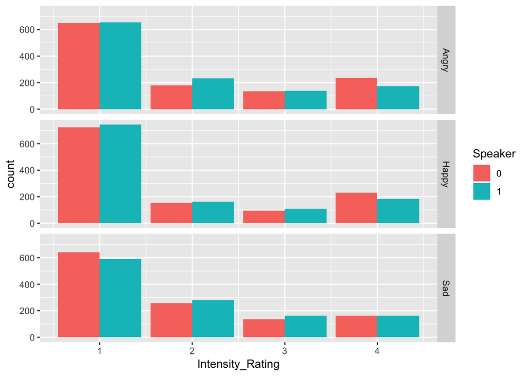

```r
ratings_acoustics_gathered$Speaker <- factor(ratings_acoustics_gathered$Speaker)
ratings_acoustics_gathered <- ratings_acoustics_gathered %>%
  filter(Intensity_Rating != 0)

ratings_acoustics_gathered %>%
  ggplot(.) +
  aes(x = Intensity_Rating, fill = Speaker) +
  facet_grid(Target_Prosody ~ .) +
  geom_bar(position = "dodge")
```

It looks like this is reverse-coded–1=4, etc. Let’s assume it is and transform it.

```r
ratings_acoustics_gathered$Intensity_Rating <- 5 - ratings_acoustics_gathered$Intensity_Rating
```

### 5.1.2 Jitter plot of Intensity_Ratings by Target_Prosody by Speaker

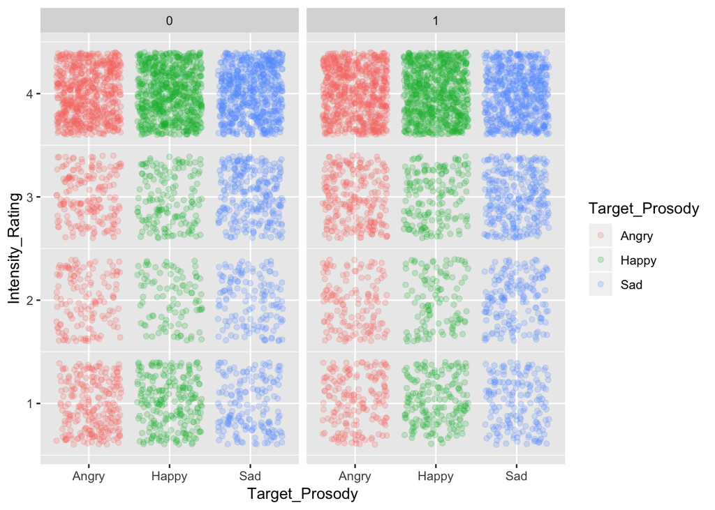

```r
ratings_acoustics_gathered %>%
  filter(Intensity_Rating != 0) %>%
  ggplot(.) +
  aes(x = Target_Prosody, y = Intensity_Rating, color = Target_Prosody, group = Subject) +
  geom_point(position = "jitter", alpha = .2) +
  facet_grid(. ~ Speaker)
```

## 5.2 Differences between speakers

The difference between speakers in perceived intensity ratings should be on [-3,3]. We need to ‘spread’ the values to calculate this. But we can’t do it because the Speaker and Target_Prosody values aren’t unique without the Script and Order variables.